# Effect of +def truncation on separable prior

# Format simulation output

Store off-diagonal samples in a vector, discarding the burnin.

```r
burnin <- 1000

empty_named_list <- function(z, element_names) {
  ans <- vector("list", length(edge_prob_seq))
  names(ans) <- element_names
  return(ans)
}

element_names <- paste("edge_prob = ", edge_prob_seq, sep='')
diagsamples1 <- lapply(1:length(kseq), empty_named_list, element_names=element_names)
names(diagsamples1) <- paste("k = ", kseq, sep='')
diagsamples2 <- offdiagsamples1 <- offdiagsamples2 <- total_edges1 <- total_edges2 <- diagsamples1


for (i in 1:length(kseq)) {
  for (j in 1:length(edge_prob_seq)) {
    diagentry <- fit1[[i]][[j]]$indexes[1,] == fit1[[i]][[j]]$indexes[2,]
    diagsamples1[[i]][[j]] <- as.vector(fit1[[i]][[j]]$postSample[-1:-burnin,diagentry])
    diagsamples2[[i]][[j]] <- as.vector(fit2[[i]][[j]]$postSample[-1:-burnin,diagentry])
    offdiagsamples1[[i]][[j]] <- as.vector(fit1[[i]][[j]]$postSample[-1:-burnin,!diagentry])
    offdiagsamples2[[i]][[j]] <- as.vector(fit2[[i]][[j]]$postSample[-1:-burnin,!diagentry])
    total_edges1[[i]][[j]] <- rowSums(as.matrix(fit1[[i]][[j]]$postSample[-1:-burnin,!diagentry] != 0))
    total_edges2[[i]][[j]] <- rowSums(as.matrix(fit2[[i]][[j]]$postSample[-1:-burnin,!diagentry] != 0))
  }
}
```

For each $k$ and edge probability, we calculate the prior edge probability after truncation, standard deviation of non-zero off-diagonal entries, and mean diagonal entry.

```r
pars <- expand.grid(k=factor(kseq), edge_prob=edge_prob_seq)

edge_prob_trunc <- sd_offdiag <- mean_diag <- matrix(NA, nrow=nrow(pars), ncol=2)
colnames(edge_prob_trunc) <- paste("lambda=",round(c(lambda1,lambda2),5))
colnames(sd_offdiag) <- colnames(mean_diag) <- colnames(edge_prob_trunc)
sd_nonzero <- function(x) sd(x[x != 0])
for (i in 1:nrow(pars)) {
  k <- pars$k[i]
  edge_prob <- pars$edge_prob[i]

  sel1 <- which(names(diagsamples1) == paste('k = ', k, sep=''))
  sel2 <- which(names(diagsamples1[[1]]) == paste('edge_prob = ', edge_prob, sep=''))

  edge_prob_trunc[i,1] <- mean(offdiagsamples1[[sel1]][[sel2]] != 0)
  edge_prob_trunc[i,2] <- mean(offdiagsamples2[[sel1]][[sel2]] != 0)
  sd_offdiag[i, 1] <- sd_nonzero(offdiagsamples1[[sel1]][[sel2]])
  sd_offdiag[i, 2] <- sd_nonzero(offdiagsamples2[[sel1]][[sel2]])
  mean_diag[i, 1] <- mean(diagsamples1[[sel1]][[sel2]])
  mean_diag[i, 2] <- mean(diagsamples2[[sel1]][[sel2]])
}
```

```r
edge_prob_trunc <- cbind(pars, edge_prob_trunc) |>
  pivot_longer(cols=3:4, names_to="lambda") |>
  mutate(value = round(value, 3)) |>
  rename(edge_prob_trunc = value) |>
  mutate(lambda = factor(lambda)) |>
  mutate(lambda = factor(lambda, levels=rev(levels(lambda))))

sd_offdiag <- cbind(pars, sd_offdiag) |>
  pivot_longer(cols=3:4, names_to="lambda") |>
  mutate(value = round(value, 3)) |>
  rename(sd_offdiag = value) |>
  mutate(lambda = factor(lambda)) |>
  mutate(lambda = factor(lambda, levels=rev(levels(lambda))))

mean_diag <- cbind(pars, mean_diag) |>
  pivot_longer(cols=3:4, names_to="lambda") |>
  mutate(value = round(value, 3)) |>
  rename(mean_diag = value) |>
  mutate(lambda = factor(lambda)) |>
  mutate(lambda = factor(lambda, levels=rev(levels(lambda))))
```

We also obtain the prior distribution of the number of edges $\sum_{i<j} Z_{ij}$, before and after truncation. The latter is estimated from MCMC output. For $Z_{ij} \sim \mbox{Bern}(\eta)$, the former is given by a Binomial distribution with $p(p-1)/2$ trials and success probability $\eta$.

```r
nedges1 <- nedges2 <- vector("list", length(total_edges1))
for (i in 1:length(total_edges1)) {
  totaledges <- as.integer(unlist(total_edges1[[i]]))
  lab <- rep(names(total_edges1[[i]]), sapply(total_edges1[[i]], length))
  nedges1[[i]] <- data.frame(nedges = totaledges, edge_prob = lab)
  #
  totaledges <- as.integer(unlist(total_edges2[[i]]))
  lab <- rep(names(total_edges2[[i]]), sapply(total_edges2[[i]], length))
  nedges2[[i]] <- data.frame(nedges = totaledges, edge_prob = lab)
}

nedges1 <- do.call(rbind, nedges1) |>
  mutate(k= rep(kseq, sapply(nedges1, nrow)))

nedges2 <- do.call(rbind, nedges2) |>
  mutate(k= rep(kseq, sapply(nedges2, nrow)))
```

We only evaluate the Binomial and Beta-Binomial priors for the largest $k$, since we will restrict the later plot to such $k$.

```r
totaledges <- max(kseq) * (max(kseq)-1) / 2
nedges_binom <- vector("list", length(edge_prob_seq))
for (j in 1:length(edge_prob_seq)) {

  if (edge_prob_seq[j] >= 0) {
    pmf_edges <- dbinom(x=0:totaledges, size=totaledges, prob=edge_prob_seq[j])
  } else {
    pmf_edges <- dbbinom(0:totaledges, size=totaledges, alpha=1, beta=2)
  }
  number_edges <- rep(0:totaledges, round(50000 * pmf_edges, 4))

  nedges_binom[[j]] <- data.frame(edge_prob=edge_prob_seq[j],
                                  number_edges = number_edges) |>
                       mutate(trunc = "Before truncation")

}
nedges_binom <- do.call(rbind, nedges_binom)
```

# Visualize results

First we display the computed quantities, and subsequently we plot them.

```r
edge_prob_trunc
```

```
## # A tibble: 10 × 4
##    k     edge_prob lambda        edge_prob_trunc
##    <fct>     <dbl> <fct>                   <dbl>
##  1 50         0.05 lambda= 1               0.036
##  2 50         0.05 lambda= 6e-05           0.05
##  3 50         0.1  lambda= 1               0.075
##  4 50         0.1  lambda= 6e-05           0.101
##  5 50         0.2  lambda= 1               0.164
##  6 50         0.2  lambda= 6e-05           0.199
##  7 50         0.4  lambda= 1               0.36
##  8 50         0.4  lambda= 6e-05           0.401
##  9 50        -1    lambda= 1               0.002
## 10 50        -1    lambda= 6e-05           0.367
```

```r
sd_offdiag
```

```
## # A tibble: 10 × 4
##    k     edge_prob lambda        sd_offdiag
##    <fct>     <dbl> <fct>              <dbl>
##  1 50         0.05 lambda= 1          0.779
##  2 50         0.05 lambda= 6e-05      1.00
##  3 50         0.1  lambda= 1          0.788
##  4 50         0.1  lambda= 6e-05      1.00
##  5 50         0.2  lambda= 1          0.816
##  6 50         0.2  lambda= 6e-05      1.00
##  7 50         0.4  lambda= 1          0.856
##  8 50         0.4  lambda= 6e-05      1.00
##  9 50        -1    lambda= 1          0.779
## 10 50        -1    lambda= 6e-05      1
```

```r
mean_diag
```

```
## # A tibble: 10 × 4
##    k     edge_prob lambda        mean_diag
##    <fct>     <dbl> <fct>             <dbl>
##  1 50         0.05 lambda= 1          2.71
##  2 50         0.05 lambda= 6e-05  32118.
##  3 50         0.1  lambda= 1          3.41
##  4 50         0.1  lambda= 6e-05  32107.
##  5 50         0.2  lambda= 1          4.71
##  6 50         0.2  lambda= 6e-05  32303.
##  7 50         0.4  lambda= 1          6.71
##  8 50         0.4  lambda= 6e-05  31965.
##  9 50        -1    lambda= 1          2.04
## 10 50        -1    lambda= 6e-05  32359.
```

## Prior distribution on the number of edges

We plot the prior distribution on the number of edges under $\lambda=1$, for a prior edge probability of 0.05 and for the Beta-Binomial model prior.

```r
data2plot <- filter(nedges1, k==max(kseq)) |>
  mutate(edge_prob = sub("edge_prob = ", "", edge_prob)) |>
  mutate(edge_prob = as.numeric(edge_prob), trunc = "After truncation") |>
  select(edge_prob, nedges, trunc) |>
  rename(number_edges = nedges) |>
  rbind(nedges_binom) |>
  mutate(edge_prob = paste("Edge probability = ", edge_prob, sep=''))
```

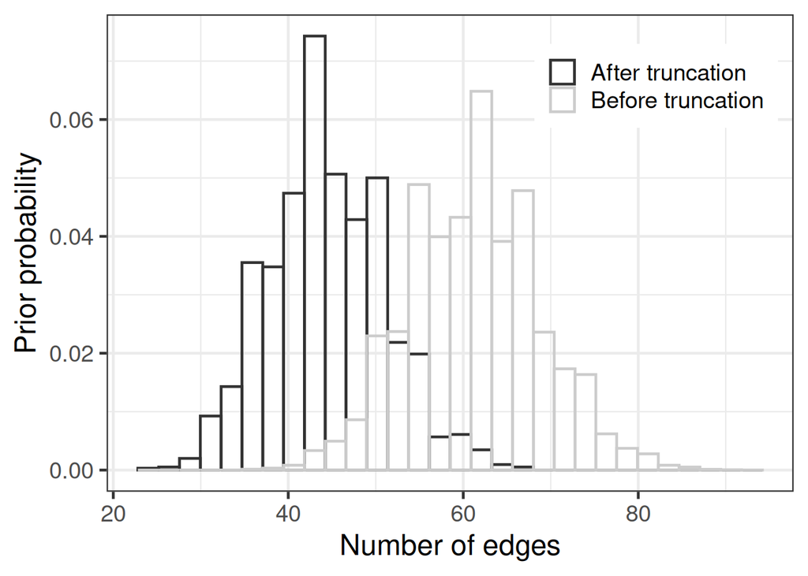

```r
filter(data2plot, edge_prob == "Edge probability = 0.05") |>
ggplot(aes(x=number_edges, col=trunc)) +
  geom_histogram(aes(y = after_stat(density)), fill=NA, position="identity") +
  theme_bw(base_size = 18) +
  theme(legend.position = c(0.8, 0.85), legend.title = element_blank()) +
  scale_color_grey() +
  xlab("Number of edges") +
  ylab("Prior probability")
```

```r
if (save2pdf) ggsave("prior_number_edges_edgeprob05.pdf")
```

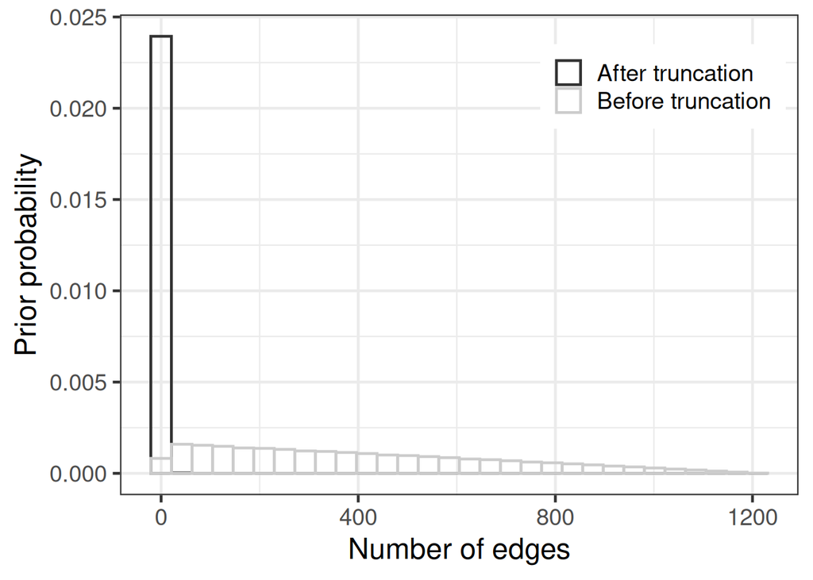

```r
filter(data2plot, edge_prob == "Edge probability = -1") |>
ggplot(aes(x=number_edges, col=trunc)) +
  geom_histogram(aes(y = after_stat(density)), fill=NA, position="identity") +
  theme_bw(base_size = 18) +
  theme(legend.position = c(0.8, 0.85), legend.title = element_blank()) +
  scale_color_grey() +
  xlab("Number of edges") +
  ylab("Prior probability")
```

```r
if (save2pdf) ggsave("prior_number_edges_edgeprob_bbin.pdf")
```

We repeat the plots, now for the smaller $\lambda$.

```r
data2plot <- filter(nedges2, k==max(kseq)) |>
  mutate(edge_prob = sub("edge_prob = ", "", edge_prob)) |>
  mutate(edge_prob = as.numeric(edge_prob), trunc = "After truncation") |>
  select(edge_prob, nedges, trunc) |>
  rename(number_edges = nedges) |>
  rbind(nedges_binom) |>
  mutate(edge_prob = paste("Edge probability = ", edge_prob, sep=''))
```

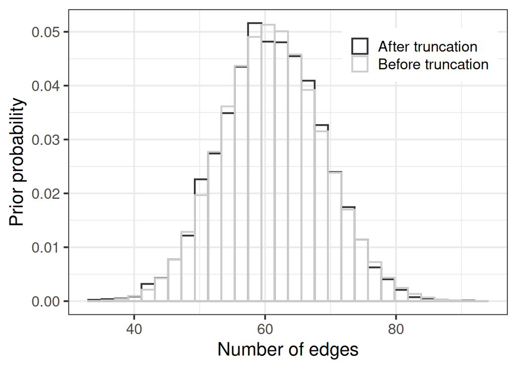

```r
filter(data2plot, edge_prob == "Edge probability = 0.05") |>
ggplot(aes(x=number_edges, col=trunc)) +
  geom_histogram(aes(y = after_stat(density)), fill=NA, position="identity") +
  theme_bw(base_size = 18) +
  theme(legend.position = c(0.8, 0.85), legend.title = element_blank()) +
  scale_color_grey() +
  xlab("Number of edges") +
  ylab("Prior probability")
```

```r
if (save2pdf) ggsave("prior_number_edges_edgeprob05_lambda2.pdf")
```

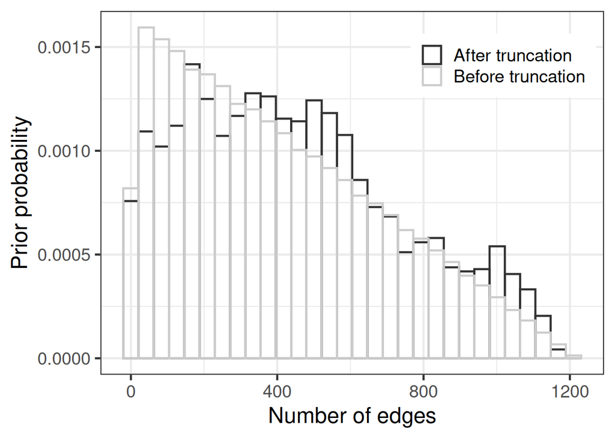

```r
filter(data2plot, edge_prob == "Edge probability = -1") |>
ggplot(aes(x=number_edges, col=trunc)) +
  geom_histogram(aes(y = after_stat(density)), fill=NA, position="identity") +
  theme_bw(base_size = 18) +
  theme(legend.position = c(0.8, 0.85), legend.title = element_blank()) +
  scale_color_grey() +
  xlab("Number of edges") +
  ylab("Prior probability")
```

```r
if (save2pdf) ggsave("prior_number_edges_edgeprob_bbin_lambda2.pdf")
```